# ExcerciseManner Prediction

#Machine Learning Course Project ##Background Using devices such as Jawbone Up, Nike FuelBand, and Fitbit it is now possible to collect a large amount of data about personal activity relatively inexpensively. These type of devices are part of the quantified self movement - a group of enthusiasts who take measurements about themselves regularly to improve their health, to find patterns in their behavior, or because they are tech geeks. One thing that people regularly do is quantify how much of a particular activity they do, but they rarely quantify how well they do it. In this project, your goal will be to use data from accelerometers on the belt, forearm, arm, and dumbell of 6 participants. They were asked to perform barbell lifts correctly and incorrectly in 5 different ways. More information is available from the website here: http://groupware.les.inf.puc-rio.br/har (see the section on the Weight Lifting Exercise Dataset).

```r
library(caret)
library(readr)
```

```r
pml_training <- read_csv("pml-training.csv")
pml_testing <- read_csv("pml-testing.csv")
```

##Data Cleaning First we will check the NA Values

```r
colSums(is.na(pml_training))
```

```
##                       X1                user_name     raw_timestamp_part_1
##                        0                        0                        0
##     raw_timestamp_part_2           cvtd_timestamp               new_window
##                        0                        0                        0
##               num_window                roll_belt               pitch_belt
##                        0                        0                        0
##                 yaw_belt         total_accel_belt       kurtosis_roll_belt
##                        0                        0                    19216
##      kurtosis_picth_belt        kurtosis_yaw_belt       skewness_roll_belt
##                    19216                    19216                    19216
##     skewness_roll_belt.1        skewness_yaw_belt            max_roll_belt
##                    19216                    19216                    19216
##           max_picth_belt             max_yaw_belt            min_roll_belt
##                    19216                    19216                    19216
##           min_pitch_belt             min_yaw_belt      amplitude_roll_belt
##                    19216                    19216                    19216
##     amplitude_pitch_belt       amplitude_yaw_belt     var_total_accel_belt
##                    19216                    19216                    19216
##            avg_roll_belt         stddev_roll_belt            var_roll_belt
##                    19216                    19216                    19216
##           avg_pitch_belt        stddev_pitch_belt           var_pitch_belt
##                    19216                    19216                    19216
##             avg_yaw_belt          stddev_yaw_belt             var_yaw_belt
##                    19216                    19216                    19216
##             gyros_belt_x             gyros_belt_y             gyros_belt_z
##                        0                        0                        0
##             accel_belt_x             accel_belt_y             accel_belt_z
##                        0                        0                        0
##            magnet_belt_x            magnet_belt_y            magnet_belt_z
##                        0                        0                        0
##                 roll_arm                pitch_arm                  yaw_arm
##                        0                        0                        0
##          total_accel_arm            var_accel_arm             avg_roll_arm
##                        0                    19216                    19216
##          stddev_roll_arm             var_roll_arm            avg_pitch_arm
##                    19216                    19216                    19216
##         stddev_pitch_arm            var_pitch_arm              avg_yaw_arm
##                    19216                    19216                    19216
##           stddev_yaw_arm              var_yaw_arm              gyros_arm_x
##                    19216                    19216                        0
```

[output cut: 53 more lines]

```
##                    19216                        0                    19216
##         avg_roll_forearm      stddev_roll_forearm         var_roll_forearm
##                    19216                    19216                    19216
##        avg_pitch_forearm     stddev_pitch_forearm        var_pitch_forearm
##                    19216                    19216                    19216
##          avg_yaw_forearm       stddev_yaw_forearm          var_yaw_forearm
##                    19216                    19216                    19216
##          gyros_forearm_x          gyros_forearm_y          gyros_forearm_z
##                        0                        0                        0
##          accel_forearm_x          accel_forearm_y          accel_forearm_z
##                        0                        0                        0
##         magnet_forearm_x         magnet_forearm_y         magnet_forearm_z
##                        0                        0                        0
##                   classe
##                        0
```

As of now we have the idea that all have the same amount NAs, which means they have NA in the same row (for each NA). So we will remove these NA columns. As almost the whole Columns contains NA values.

```r
dataNA <- colSums(is.na(pml_training)) > 0
pml_training <- pml_training[,!dataNA]
pml_testing <- pml_testing[,!dataNA]
#Removing Irrelevant columns from our dataset i.e. X1,raw_timestamp_part_1, raw_timestamp_part_,2 cvtd_timestamp, new_window, and  num_window.
pml_training<- pml_training[,-c(1,3,4,5,6,7)]
pml_testing<- pml_testing[,-c(1,3,4,5,6,7)]
```

##Exploratory Data Analysis

Now lets plot some chart to see overall trend.

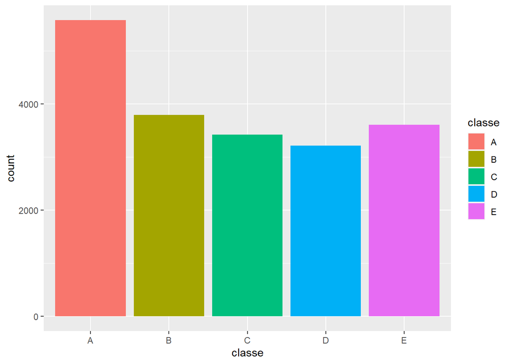

```r
ggplot(data = pml_training,aes(x=classe, fill= classe))+geom_bar()
```

##Prediction Model

```r
Partition<- createDataPartition(y=pml_training$classe, p=0.7,list=FALSE)
trainingset <- pml_training[Partition,]
testingset <- pml_training[-Partition,]

trainingset$classe <- factor(trainingset$classe)
testingset$classe <- factor(testingset$classe)
```

##Starting with Random Forest

```r
library(randomForest)
modelfit_rf <- randomForest(classe ~ ., data = trainingset)
predict_rf <- predict(modelfit_rf, testingset )

confusionMatrix(predict_rf,testingset$classe)
```

```
## Confusion Matrix and Statistics
##
##           Reference
## Prediction    A    B    C    D    E
##          A 1671    7    0    0    0
##          B    1 1132    1    0    0
##          C    0    0 1025    8    2
##          D    1    0    0  953    2
##          E    1    0    0    3 1078
##
## Overall Statistics
##
##                Accuracy : 0.9956
##                  95% CI : (0.9935, 0.9971)
##     No Information Rate : 0.2845
##     P-Value [Acc > NIR] : < 2.2e-16
##
##                   Kappa : 0.9944
##
##  Mcnemar's Test P-Value : NA
##
## Statistics by Class:
##
##                      Class: A Class: B Class: C Class: D Class: E
## Sensitivity            0.9982   0.9939   0.9990   0.9886   0.9963
## Specificity            0.9983   0.9996   0.9979   0.9994   0.9992
## Pos Pred Value         0.9958   0.9982   0.9903   0.9969   0.9963
## Neg Pred Value         0.9993   0.9985   0.9998   0.9978   0.9992
## Prevalence             0.2845   0.1935   0.1743   0.1638   0.1839
## Detection Rate         0.2839   0.1924   0.1742   0.1619   0.1832
## Detection Prevalence   0.2851   0.1927   0.1759   0.1624   0.1839
## Balanced Accuracy      0.9983   0.9967   0.9985   0.9940   0.9977
```

Turned out that RandomForest Accuracy is really good.

##Variable Importance As we already know the accuracy of our model. Lets have a look at the important features.

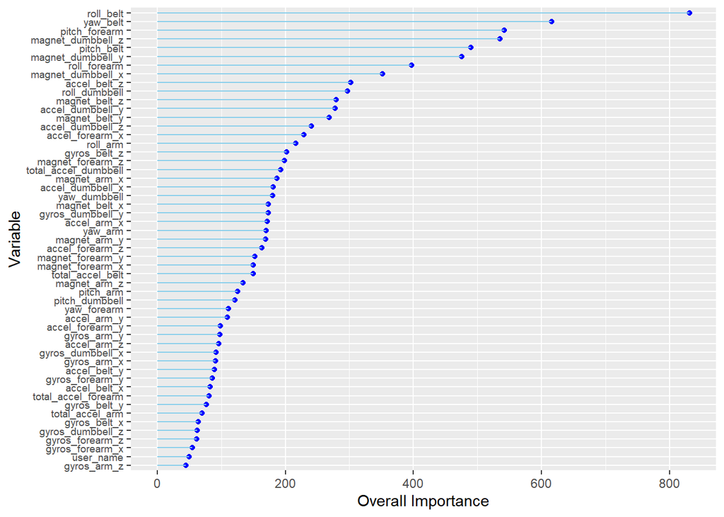

```r
varImp <- varImp(modelfit_rf)

ggplot(varImp,aes(x=reorder(rownames(varImp),Overall), y= Overall))+ geom_point(colour = "blue")+geom_segment( aes(x=rownames(varImp), xend=rownames(varImp), y=0, yend=Overall),color='skyblue')+theme(axis.text.y = element_text(size = 7))+coord_flip()+xlab('Variable')+
ylab('Overall Importance')
```

##Test Set Prediction

```r
FinalPrediction <- predict(modelfit_rf,pml_testing)
FinalPrediction
```

```
##  1  2  3  4  5  6  7  8  9 10 11 12 13 14 15 16 17 18 19 20
##  B  A  B  A  A  E  D  B  A  A  B  C  B  A  E  E  A  B  B  B
## Levels: A B C D E
```